# Tarea 12

Joshua Cervantes

30 August, 2024

```r
#Se establece el directorio al archivo fuente
#try(setwd(dirname(rstudioapi::getActiveDocumentContext()$path)))
#try(setwd("C:\\Users\\User\\OneDrive - Universidad de Costa Rica\\Documents\\UCR\\2024\\Topicos_de_analisis_de_datos_2\\tareas\\tarea_10"))
knitr::opts_chunk$set(warnings = FALSE, message = FALSE)
#Se cargan los paquete
library(RSDA)
library(ggpolypath)
library(tidyverse)
library(kableExtra)
#Se establece el tema por defecto para los graficos
theme_set(theme_minimal())
```

# Ejercicio 1

```r
# Se carga la data
library(MASS)
data(painters)
painters
```

```
##                 Composition Drawing Colour Expression School
## Da Udine                 10       8     16          3      A
## Da Vinci                 15      16      4         14      A
## Del Piombo                8      13     16          7      A
## Del Sarto                12      16      9          8      A
## Fr. Penni                 0      15      8          0      A
## Guilio Romano            15      16      4         14      A
## Michelangelo              8      17      4          8      A
## Perino del Vaga          15      16      7          6      A
## Perugino                  4      12     10          4      A
## Raphael                  17      18     12         18      A
## F. Zucarro               10      13      8          8      B
## Fr. Salviata             13      15      8          8      B
## Parmigiano               10      15      6          6      B
## Primaticcio              15      14      7         10      B
## T. Zucarro               13      14     10          9      B
## Volterra                 12      15      5          8      B
## Barocci                  14      15      6         10      C
## Cortona                  16      14     12          6      C
## Josepin                  10      10      6          2      C
## L. Jordaens              13      12      9          6      C
## Testa                    11      15      0          6      C
## Vanius                   15      15     12         13      C
## Bassano                   6       8     17          0      D
## Bellini                   4       6     14          0      D
## Giorgione                 8       9     18          4      D
## Murillo                   6       8     15          4      D
## Palma Giovane            12       9     14          6      D
## Palma Vecchio             5       6     16          0      D
## Pordenone                 8      14     17          5      D
## Tintoretto               15      14     16          4      D
## Titian                   12      15     18          6      D
## Veronese                 15      10     16          3      D
## Albani                   14      14     10          6      E
## Caravaggio                6       6     16          0      E
## Corregio                 13      13     15         12      E
## Domenichino              15      17      9         17      E
## Guercino                 18      10     10          4      E
## Lanfranco                14      13     10          5      E
## The Carraci              15      17     13         13      E
## Durer                     8      10     10          8      F
## Holbein                   9      10     16         13      F
## Pourbus                   4      15      6          6      F
## Van Leyden                8       6      6          4      F
## Diepenbeck               11      10     14          6      G
## J. Jordaens              10       8     16          6      G
## Otho Venius              13      14     10         10      G
## Rembrandt                15       6     17         12      G
## Rubens                   18      13     17         17      G
## Teniers                  15      12     13          6      G
## Van Dyck                 15      10     17         13      G
## Bourdon                  10       8      8          4      H
## Le Brun                  16      16      8         16      H
## Le Suer                  15      15      4         15      H
## Poussin                  15      17      6         15      H
```

## a

```r
# Se construye una tabla simbolica
(sym_painters <- classic.to.sym(painters, concept = "School"))
```

```
## # A tibble: 8 × 4
##       Composition         Drawing          Colour     Expression
##        <symblc_n>      <symblc_n>      <symblc_n>     <symblc_n>
## 1  [0.00 : 17.00]  [8.00 : 18.00]  [4.00 : 16.00] [0.00 : 18.00]
## 2 [10.00 : 15.00] [13.00 : 15.00]  [5.00 : 10.00] [6.00 : 10.00]
## 3 [10.00 : 16.00] [10.00 : 15.00]  [0.00 : 12.00] [2.00 : 13.00]
## 4  [4.00 : 15.00]  [6.00 : 15.00] [14.00 : 18.00]  [0.00 : 6.00]
## 5  [6.00 : 18.00]  [6.00 : 17.00]  [9.00 : 16.00] [0.00 : 17.00]
## 6   [4.00 : 9.00]  [6.00 : 15.00]  [6.00 : 16.00] [4.00 : 13.00]
## 7 [10.00 : 18.00]  [6.00 : 14.00] [10.00 : 17.00] [6.00 : 17.00]
## 8 [10.00 : 16.00]  [8.00 : 17.00]   [4.00 : 8.00] [4.00 : 16.00]
```

## b

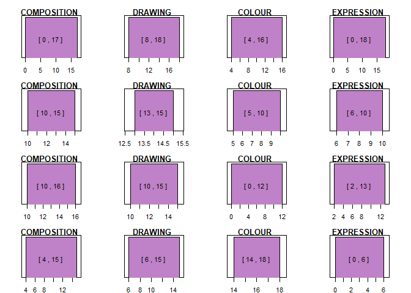

```r
#Grafico de la tabla resultante
plot(sym_painters[1:4,])
```

## c

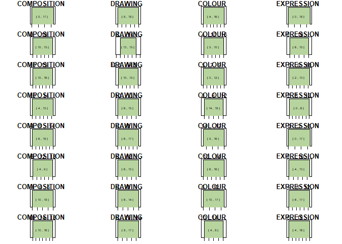

```r
# Se procede a graficar toda la tabla
plot(sym_painters)
```

## d

```r
# Se procede a estimar la media sinbolica

lapply(sym_painters, FUN = mean, method = "interval")
```

```
## $Composition
## <symbolic_interval[1]>
## [1] [6.75 : 15.50]
##
## $Drawing
## <symbolic_interval[1]>
## [1] [7.88 : 15.75]
##
## $Colour
## <symbolic_interval[1]>
## [1] [6.50 : 14.12]
##
## $Expression
## <symbolic_interval[1]>
## [1] [2.75 : 13.75]
```

```r
# Se procede a estimar la mediana
lapply(sym_painters, FUN = median, method = "interval")
```

```
## $Composition
## <symbolic_interval[1]>
## [1] [8.00 : 16.00]
##
## $Drawing
## <symbolic_interval[1]>
## [1] [7.00 : 15.00]
##
## $Colour
## <symbolic_interval[1]>
## [1] [5.50 : 16.00]
##
## $Expression
## <symbolic_interval[1]>
## [1] [3.00 : 14.50]
```

```r
# Se procede a estimar la varianza
lapply(sym_painters, FUN = var, method = "interval")
```

```
## $Composition
## <symbolic_interval[1]>
## [1] [14.79 : 8.29]
##
## $Drawing
## <symbolic_interval[1]>
## [1] [6.41 : 1.93]
##
## $Colour
## <symbolic_interval[1]>
## [1] [18.86 : 13.27]
##
## $Expression
## <symbolic_interval[1]>
## [1] [6.79 : 17.07]
```

```r
# Se procede a estimar la desviacion estandar
lapply(sym_painters, FUN = sd, method = "interval")
```

```
## $Composition
## <symbolic_interval[1]>
## [1] [3.85 : 2.88]
##
## $Drawing
## <symbolic_interval[1]>
## [1] [2.53 : 1.39]
##
## $Colour
## <symbolic_interval[1]>
## [1] [4.34 : 3.64]
##
## $Expression
## <symbolic_interval[1]>
## [1] [2.60 : 4.13]
```

```r
# Se procede a estimar la desviacion estandar
cor(sym_painters$Composition, sym_painters$Drawing)
```

```
## [1] 0.1985345
```

## e

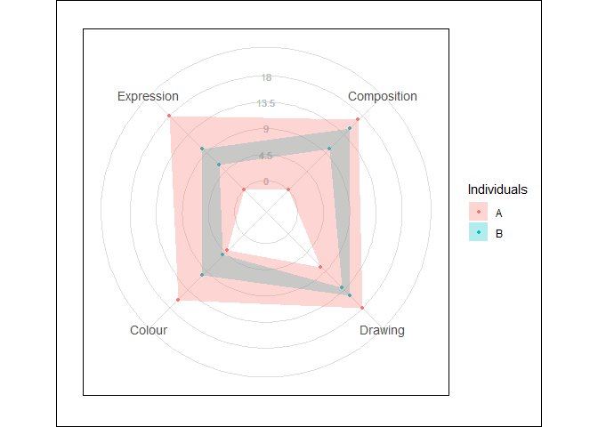

```r
# Se realiza un grafico de radar
sym.radar.plot(sym_painters[1:2,])
```

En este caso se puede observar que el individuo A presenta una mayor varianza en todas las mediciones en comparación con el individuo B. Además, se puede observar que el individuo B presenta una menor varianza en la variable de Drawing. Por lo que puede decirse que el individuo B es más consistente.

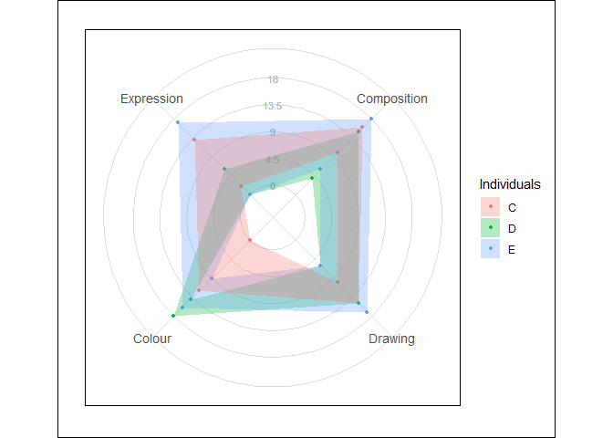

```r
# Se realiza un grafico de radar
sym.radar.plot(sym_painters[3:5,])
```

## f

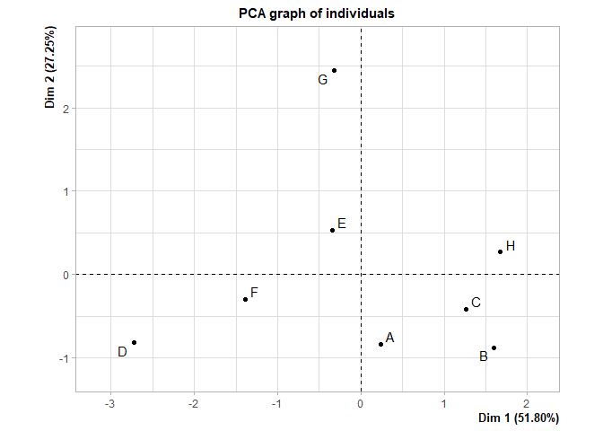

```r
# Se realiza un ACP con el metodo
# clasico
acp_classic_painters <- sym.pca(sym_painters, 'classic')
plot(acp_classic_painters, choix='ind')
```

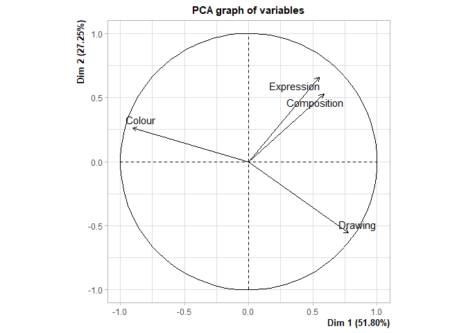

```r
plot(acp_classic_painters, choix='var')
```

Se puede observar en el círculo de correlaciones que las variables de Expression y Composition de acuerdo a los puntos medios son las que presentan la mayor correlación. Mientras las de Colour y Drawing son las que presentan menor correlación. Se puede observar que las 4 variable se pueden considerar bien representadas en el plano principal.

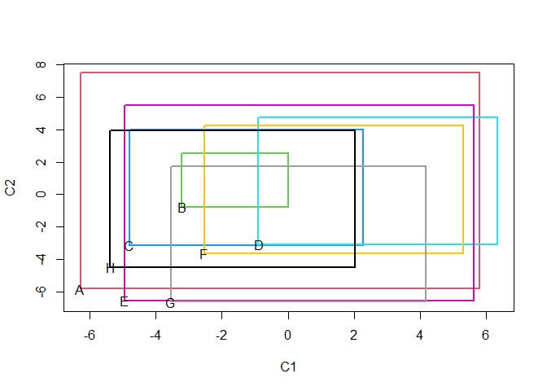

```r
# Se realiza un ACP con el metodo
# simbolico
acp_sym_painters <- sym.pca(sym_painters, method = 'centers')
plot(acp_sym_painters, choix='ind')
```

Al observar el ACP simbólico se puede observar que el individuo A es el que presenta la mayor variabilidad al presentar una caja con mayor área. Por otro lado se puede observar que el individuo que presenta la menor variabilidad es el B que posee una menor área. Se puede destacar el hecho de que todos los individuos se encuentran sobreposicionados.

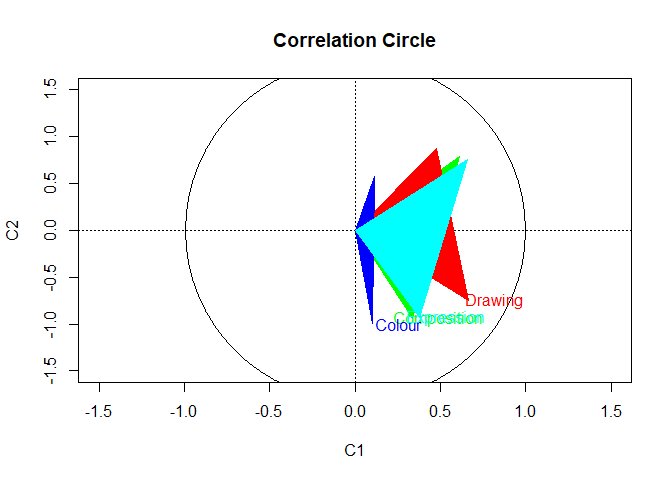

```r
plot(acp_sym_painters, choix='var')
```

Aquí se puede observar que la variable que se ve menos representada es lade colour. Sin embargo, el resto presentan una representación, similar. Se puede observar que de las tres que presentan la mejor representación, Composotion y Drawing son los que presentan la posible menor correlación a tener uno de los ángulos más grandes, y algo similar ocurre entre Drawing y Expression. Composition y Expression presentan un comportamiento similar.

## g

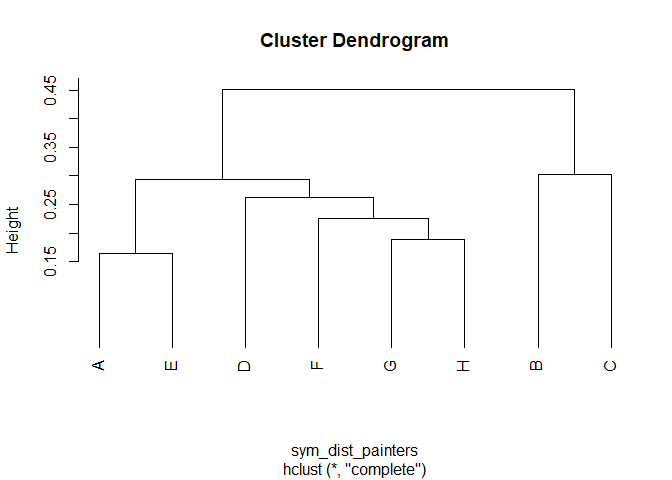

```r
# Se hace una clusterizacion jeraquica
sym_dist_painters <- sym.dist.interval(sym.data = sym_painters,
                        method = "Gowda.Diday")
sym_hclust_painters <- hclust(sym_dist_painters)
plot(sym_hclust_painters, hang = -1)
```

En este caso con la distancia de Gowda-Diday se puede observar que A y E son los que presentan una menor distancia entre los individuos. Además, D, F, G y JH presentan distancias similares entre si. Cabe destacrar que los que se encutran más alejados son B y C, incluso entre si.

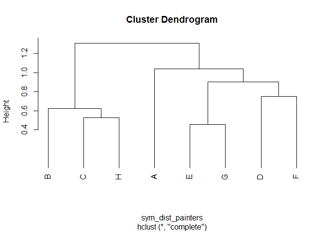

```r
#Billard distance
sym_dist_painters <- sym.dist.interval(sym.data = sym_painters,
                        method = "Ichino")
sym_hclust_painters <- hclust(sym_dist_painters)
plot(sym_hclust_painters, hang = -1)
```

Con la distancia de Ichino se puede observar que los individuos que presentan una menor distancia son E y G. Además B, C y H presentan una distancia similar entre si, pero se encuentran alejados de los demás. El resto de elementos parecen encontrarse alejados.

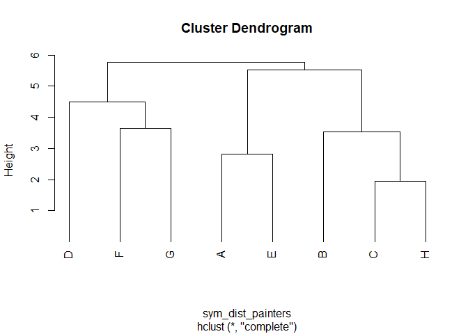

```r
#Billard distance
sym_dist_painters <- sym.dist.interval(sym.data = sym_painters,
                        gamma = 0.5,
                        method = "Hausdorff",
                        normalize = FALSE,
                        SpanNormalize = TRUE,
                        euclidea = TRUE,
                        q = 2)
sym_hclust_painters <- hclust(sym_dist_painters)
plot(sym_hclust_painters, hang = -1)
```

Según la distancia de Hausdorff se puede observar que una vez más A y E se encuentran agrupados como con la distancia de Gowda-Diday. Sin embargo, con esta distancia se obtiene claramente una distancia entre todos los teniendo que los más cercanos son C y H como en el caso de la distancia de Ichino.

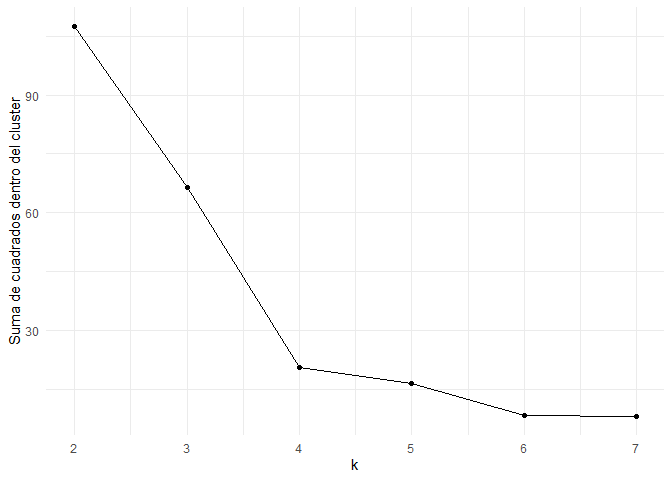

```r
tot.withinss <- c()
k <- c()

for(i in 2:7){

  # Se efectua un kmeans
   k <- c(k, i)
   tot.withinss <- c(tot.withinss,
    sym.kmeans(sym_painters, k = i)$tot.withinss)
}

ggplot(, aes(x = k, tot.withinss)) +
  geom_point() +
  geom_line() +
  labs(x = "k", y = "Suma de cuadrados dentro del cluster")
```

Se nota claramente un codo en 4, por lo que se toma este valor. Se muestra el cluster al que pertenece el individuo y la tabla nuevamente para interpretar los resultados

```r
# Se efectua un kmeans
sym_kmeans_painter <- sym.kmeans(sym_painters, k = 4)
sym_kmeans_painter$cluster
```

```
## A B C D E F G H
## 3 4 4 1 2 3 2 4
```

```r
sym_painters
```

```
## # A tibble: 8 × 4
##       Composition         Drawing          Colour     Expression
##        <symblc_n>      <symblc_n>      <symblc_n>     <symblc_n>
## 1  [0.00 : 17.00]  [8.00 : 18.00]  [4.00 : 16.00] [0.00 : 18.00]
## 2 [10.00 : 15.00] [13.00 : 15.00]  [5.00 : 10.00] [6.00 : 10.00]
## 3 [10.00 : 16.00] [10.00 : 15.00]  [0.00 : 12.00] [2.00 : 13.00]
## 4  [4.00 : 15.00]  [6.00 : 15.00] [14.00 : 18.00]  [0.00 : 6.00]
## 5  [6.00 : 18.00]  [6.00 : 17.00]  [9.00 : 16.00] [0.00 : 17.00]
## 6   [4.00 : 9.00]  [6.00 : 15.00]  [6.00 : 16.00] [4.00 : 13.00]
## 7 [10.00 : 18.00]  [6.00 : 14.00] [10.00 : 17.00] [6.00 : 17.00]
## 8 [10.00 : 16.00]  [8.00 : 17.00]   [4.00 : 8.00] [4.00 : 16.00]
```

Se puede obsevar que el individuo D queda solo. En el ACP clásico se había observado que de hecho este individuo quedaba alejado de los demás y al observar el ACP simbólico se puede ver que este individuo sí presenta una tendencia hacia la derecha que no presentan los demás. B, C y H quedan el mismo cluster, de hecho si se observar el ACP simbólico se puede observar que las cajas de B y C se ven contenidas en H.

A queda con F si observa a pesar de que A muestra la mayor variabilidad este presenta valores similares en Colour a F. Esta variable es la peor representada en el plano prinicipal.

Finanlmente se puede observar que quedaron juntos E y G, de hecho con la distancia Ichino se obtenie que estos son los que presentan la menor distancia.

# Ejercicio 2

```r
# Se leen los datos de accidentes
df_accidents <- read.csv("./Datos/accidents_2017.csv")

# Se muestran los nombres de las columnas
df_accidents %>% colnames
```

```
##  [1] "Id"                "District.Name"     "Neighborhood.Name"
##  [4] "Street"            "Weekday"           "Month"
##  [7] "Day"               "Hour"              "Part.of.the.day"
## [10] "Mild.injuries"     "Serious.injuries"  "Victims"
## [13] "Vehicles.involved" "Longitude"         "Latitude"
```

```r
df_accidents %>%head
```

```
##                Id District.Name          Neighborhood.Name
## 1 2017S008429           Unknown                    Unknown
## 2 2017S007316           Unknown                    Unknown
## 3 2017S010210           Unknown                    Unknown
## 4 2017S006364           Unknown                    Unknown
## 5 2017S004615        Sant Martí el Camp de l'Arpa del Clot
## 6 2017S007775        Sant Martí el Camp de l'Arpa del Clot
##                                               Street   Weekday     Month Day
## 1 Número 27                                             Friday   October  13
## 2 Número 3 Zona Franca / Número 50 Zona Franca          Friday September   1
## 3 Litoral (Besòs)                                       Friday  December   8
## 4 Número 3 Zona Franca                                  Friday      July  21
## 5 Las Navas de Tolosa                                 Thursday       May  25
## 6 Indústria / Trinxant                               Wednesday September  20
##   Hour Part.of.the.day Mild.injuries Serious.injuries Victims Vehicles.involved
## 1    8         Morning             2                0       2                 2
## 2   13         Morning             2                0       2                 2
## 3   21       Afternoon             5                0       5                 2
## 4    2           Night             1                0       1                 2
## 5   14       Afternoon             1                0       1                 3
## 6   12         Morning             1                0       1                 2
##   Longitude Latitude
## 1  2.125624 41.34004
## 2  2.120452 41.33943
## 3  2.167356 41.36089
## 4  2.124529 41.33767
## 5  2.185272 41.41636
## 6  2.183245 41.41634
```

```r
# Se convierte a tipo simbolico segun las tablas
# seleccionadas y la variable Neighborhood.Name
sym_accidents <- classic.to.sym(df_accidents,
  concept =  "Neighborhood.Name",
  variables = c("Mild.injuries",
    "Victims",
    "Vehicles.involved",
    "Longitude",
    "Latitude",
    "Hour"
    )
)
```

## a

```r
# Se procede a estimar la media sinbolica
lapply(sym_accidents, FUN = mean, method = "interval")
```

```
## $Mild.injuries
## <symbolic_interval[1]>
## [1] [0.00 : 4.57]
##
## $Victims
## <symbolic_interval[1]>
## [1] [0.01 : 4.58]
##
## $Vehicles.involved
## <symbolic_interval[1]>
## [1] [0.95 : 5.16]
##
## $Longitude
## <symbolic_interval[1]>
## [1] [2.15 : 2.18]
##
## $Latitude
## <symbolic_interval[1]>
## [1] [41.40 : 41.42]
##
## $Hour
## <symbolic_interval[1]>
## [1] [0.86 : 22.68]
```

```r
# Se procede a estimar la mediana
lapply(sym_accidents, FUN = median, method = "interval")
```

```
## $Mild.injuries
## <symbolic_interval[1]>
## [1] [0.00 : 4.00]
##
## $Victims
## <symbolic_interval[1]>
## [1] [0.00 : 4.00]
##
## $Vehicles.involved
## <symbolic_interval[1]>
## [1] [1.00 : 5.00]
##
## $Longitude
## <symbolic_interval[1]>
## [1] [2.15 : 2.18]
##
## $Latitude
## <symbolic_interval[1]>
## [1] [41.40 : 41.43]
##
## $Hour
## <symbolic_interval[1]>
## [1] [0.00 : 23.00]
```

```r
# Se procede a estimar la varianza
lapply(sym_accidents, FUN = var, method = "interval")
```

```
## $Mild.injuries
## <symbolic_interval[1]>
## [1] [0.00 : 3.10]
##
## $Victims
## <symbolic_interval[1]>
## [1] [0.01 : 3.15]
##
## $Vehicles.involved
## <symbolic_interval[1]>
## [1] [0.05 : 5.37]
##
## $Longitude
## <symbolic_interval[1]>
## [1] [0.00 : 0.00]
##
## $Latitude
## <symbolic_interval[1]>
## [1] [0.00 : 0.00]
##
## $Hour
## <symbolic_interval[1]>
## [1] [4.91 : 0.39]
```

```r
# Se procede a estimar la desviacion estandar
lapply(sym_accidents, FUN = sd, method = "interval")
```

```
## $Mild.injuries
## <symbolic_interval[1]>
## [1] [0.00 : 1.76]
##
## $Victims
## <symbolic_interval[1]>
## [1] [0.12 : 1.78]
##
## $Vehicles.involved
## <symbolic_interval[1]>
## [1] [0.23 : 2.32]
##
## $Longitude
## <symbolic_interval[1]>
## [1] [0.03 : 0.02]
##
## $Latitude
## <symbolic_interval[1]>
## [1] [0.03 : 0.02]
##
## $Hour
## <symbolic_interval[1]>
## [1] [2.22 : 0.62]
```

```r
# Se procede a estimar la desviacion estandar
cor(sym_accidents$Mild.injuries, sym_accidents$Hour)
```

```
## [1] -0.1945301
```

## b

Se realizan dos graficos de radar, primero se seleccionan los tres primeros conceptos. Se eliminan la latitud y longitud

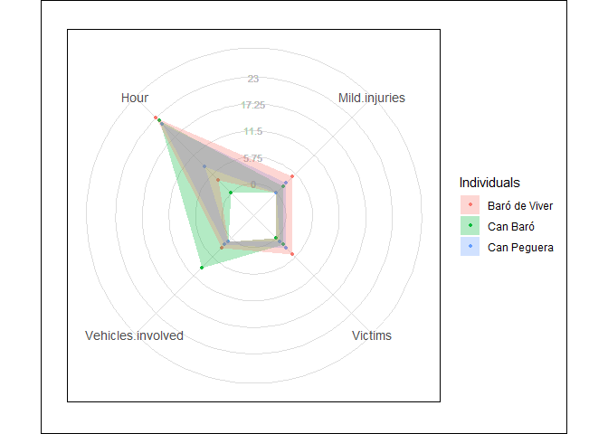

```r
sym.radar.plot(sym_accidents[1:3, c(1,2,3,6)])
```

Se puede observar que en este caso Can Baró es el que muestra la mayo variabilidad en cuanto a la cantidad de vehículos involucrados en los accidentes. Sin embargo, Baró de Viver muestra tener valores más altos de cantidad de heridas menores. Todos presentan valores altos en las horas, no obstante, Can Baró presenta mayor variabilidad al tener horas menores.

Se seleccionan las filas 5 a 8.

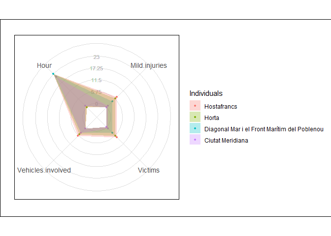

```r
sym.radar.plot(sym_accidents[rev(5:8), c(1,2,3,6)])
```

En ese caso se puede observar que todos presentan un comporatamiento similar, sin embargo, se encuentra que Hostafrancs presenta valores más altos de víctima, vehículos involucrados y heridas menores. En el caso de Ciutat Meridiana se encuentra que presenta una menor variabilidad que todos los demás vecindarios.

## c

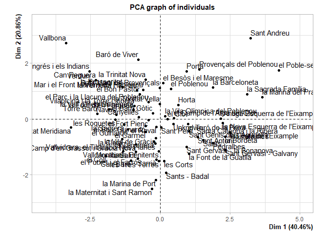

```r
# Se realiza un ACP con el metodo
# clasico
acp_classic_accidents <- sym.pca(sym_accidents, 'classic')
plot(acp_classic_accidents, choix='ind')
```

En este caso se puede observar que existen vecindarios que se alejan claramente de lo demás como Vallbona y Sant Andreu. Los demás tienen a agruparse de cierta forma.

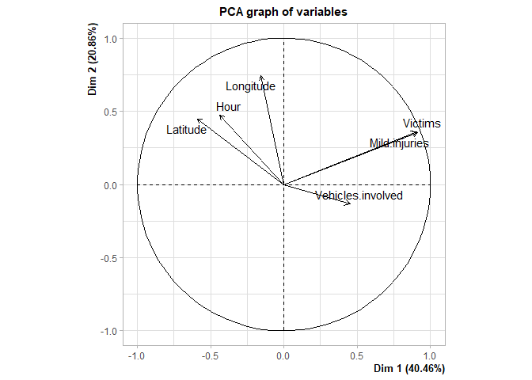

```r
plot(acp_classic_accidents, choix='var')
```

Se puede observar que existe gran correlación entre la cantidad de victimas y las heridas menores. La variable que se ve menos representada en este plano es la cantidad de vehículos involucrados.

Se realiza un ACP simbólico.

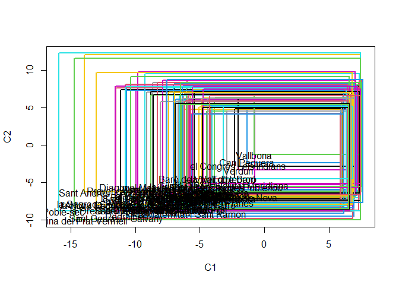

```r
# Se realiza un ACP con el metodo
# simbolico
acp_sym_accidents <- sym.pca(sym_accidents, 'centers')
plot(acp_sym_accidents, choix='ind')
```

En este caso se encuentra que Vallbona presenta una menor variabilidad, mientras que Marina del Prat Vermell presenta la mayor variabilidad. Se observa que todos presentan una variabilidad similar.

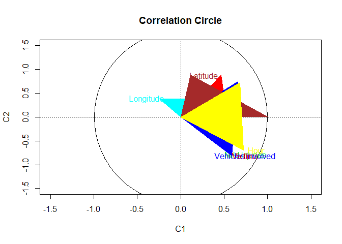

```r
plot(acp_sym_accidents, choix='var')
```

En este caso se puede observar que el longitud son las que parecen tener menor representación en este plano. Las variables de vehículos involucrados y la hora tienen un representación similar. Las variables que presentan una de las menores correlaciones son los vehículos involucrados y la longitud. Los vehículos involucrados y las horas presentan la mayor correlación.

## d

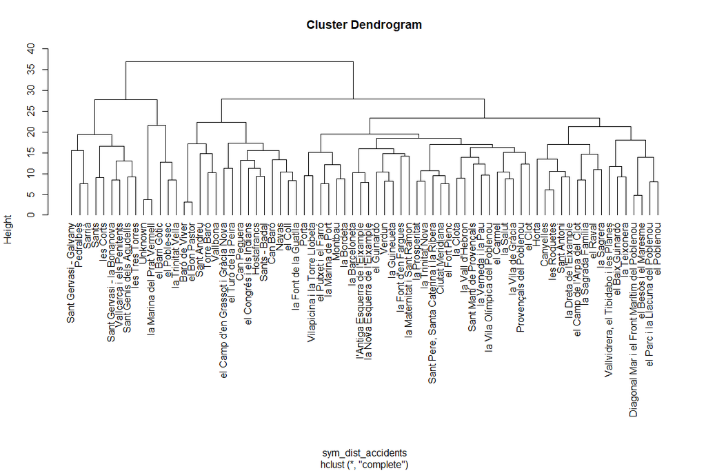

```r
# Se hace una clusterizacion jeraquica
sym_dist_accidents <- sym.dist.interval(sym.data = sym_accidents,
                        method = "Gowda.Diday")
sym_hclust_accidents <- hclust(sym_dist_accidents)
plot(sym_hclust_accidents, hang = -1)
```

Se puede observar que se pueden formar 8 conjuntos si se corta en el tercer nivel contando desde arriba hacia abajo, esto dado que en este nivel se puede observar que las distancias son menores.

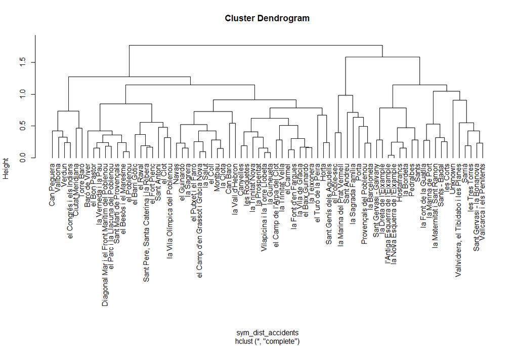

```r
#Billard distance
sym_dist_accidents <- sym.dist.interval(sym.data = sym_accidents,
                        method = "Ichino")
sym_hclust_accidents <- hclust(sym_dist_accidents)
plot(sym_hclust_accidents, hang = -1)
```

En este caso también se puede observar que existen claramente dos conjuntos ya que muestran una gran distancia en los niveles más altos. Sin embargo, en este caso también puede decidirse hace 8 grupos, no obstante en comparación con la distancia anterior aquí se muestran distancias más alejadas.

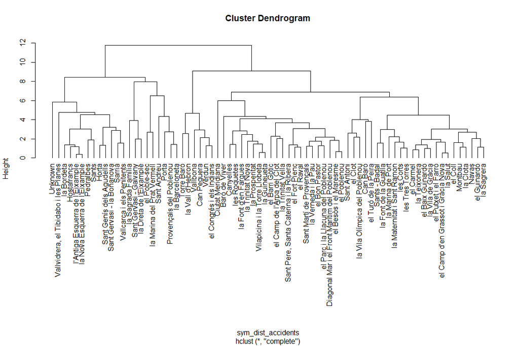

```r
#Billard distance
sym_dist_accidents <- sym.dist.interval(sym.data = sym_accidents,
                        gamma = 0.5,
                        method = "Hausdorff",
                        normalize = FALSE,
                        SpanNormalize = TRUE,
                        euclidea = TRUE,
                        q = 2)
sym_hclust_accidents <- hclust(sym_dist_accidents)
plot(sym_hclust_accidents, hang = -1)
```

Con esta distancia se puede obsservar que existen muchos elementos que tienen una gran distancia entre si, esto en comparación con las dos distancias anteriores. Sin embargo, se puede ver una menor distancia en algunos elementos del primero nivel.

## e

Para poder ver el numero de clusters optimo se realiza el grafico del codo para diferentes valores de k.

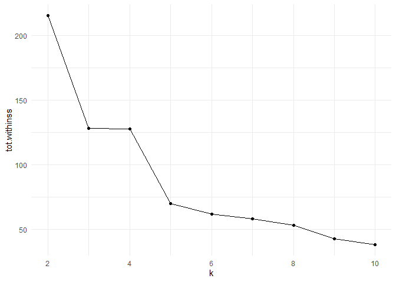

```r
tot.withinss <- c()
k <- c()

for(i in 2:10){

  # Se efectua un kmeans
   k <- c(k, i)
   tot.withinss <- c(tot.withinss,
    sym.kmeans(sym_accidents, k = i)$tot.withinss)
}

ggplot(, aes(x = k, tot.withinss)) +
  geom_point() +
  geom_line() +
  labs(x = "k", "Suma de cuadrados dentro del cluster")
```

Se puede observar que hay un codo cerca de 5, sin embargo, el valor sigue disminuyendo por lo que se pude observar que el gráfico se estabiliza en 7. Entonces se toma este valor.

En este caso se presentan los centros para interpretación.

```r
sym_kmeans_accidents <- sym.kmeans(sym_accidents, k = 7)
sym_kmeans_accidents$centers
```

```
##   Mild.injuries  Victims Vehicles.involved Longitude Latitude     Hour
## 1      2.785714 2.785714          5.857143  2.160471 41.40428 11.35714
## 2      1.333333 1.333333          2.277778  2.160369 41.41715 11.22222
## 3      1.500000 1.600000          2.500000  2.169771 41.43646 15.10000
## 4      3.642857 3.678571          3.035714  2.159148 41.40045 11.46429
## 5      2.195652 2.195652          2.413043  2.170959 41.41111 11.76087
## 6      1.892857 1.892857          3.214286  2.164490 41.40995 11.46429
## 7      1.000000 1.000000          4.500000  2.170399 41.42814 11.75000
```

El grupo 4 tiene valores más altos de heridas menores y víctimas, pero menor cantidad de vehículos involucrados en comparación con el grupo 1. El grupo 5 es similar al grupo 3 salvo tener horas similares a la mayoría de los elementos. Los dos últimos presentas valores similares y en comparación con todos los demás conjuntos se puede decir que se encuentran en el medio de estos.

# Ejercicio 3

En este caso se van a usar los datos del proyecto que ha sido llamado PMAP. Los datos provienen de Reiss y Stricker (2012). Los mismo corresponden a métricas que se realizaron a 9 sujetos con 3 unidades de medida inercial (IMUs) y monitores de ritmo cardiaco. Los sensores fueron colocados en 3 partes del cuerpo de cada individuo. Se colocó uno en el pecho, uno en la mano dominante y uno en el tobillo de la pierna dominante. Los sensores cuentas con dos acelerometros, un giroscopio y un magnetometro todos funcionando en tres ejes. Por lo que, posteriormente se va ver que para cada parte del IMU se tienen tres valores.

Las variables de la tabla original son:

- timestamp: Momento en que se tomó la métrica.
- actividad: En donde se ubican:
- lying
- sitting
- standing
- walking
- running
- cycling
- Nordic walking
- watching TV
- computer work
- car driving
- ascending stairs
- descending stairs
- vacuum cleaning
- ironing
- folding laundry
- house cleaning
- playing soccer
- rope jumping
- other (transient activities)
- ritmo_cardiaco: Es el ritmo cardiaco
- Posteriormente se encuentran las variables relacionadas con la temperatura de cada parte
- Se encuentran las variables relacionadas con cada parte del sensor (dos acelerometros, un giroscopio y un magnetometro) a cada una de estasa variables se le ha puesto la parte del cuerpo, la parte del dispositivo y se le ha asignado un número.

```r
dir <- paste("./pamap2+physical+activity+monitoring/subject10", 1:9, ".dat", sep = "")

# Se procede a leer estos archivos y unirlos en uno solo
df_pamap <- read.table(dir[1])
df_pamap <- df_pamap %>%
  mutate(individuo = 1)

for(i in 2:9){
  # Se procede a leer estos archivos y unirlos en uno solo
  df_pamap_aux <- read.table(dir[i])
  df_pamap_aux <- df_pamap_aux %>%
    mutate(individuo = i)

  df_pamap <- df_pamap %>%
    rbind(df_pamap_aux)

  rm(df_pamap_aux)

}
```

```r
save(file = "./pamap2+physical+activity+monitoring/pamap.RData", df_pamap)
```

```r
# Se va cambiar el nombre de las variables
# y las variables

mano <- c("mano_temp",
    "aceleracion_mano_1",
    "aceleracion_mano_2",
    "aceleracion_mano_3",
    "aceleracion_mano_4",
    "aceleracion_mano_5",
    "aceleracion_mano_6",
    "giroscopio_mano_1",
    "giroscopio_mano_2",
    "giroscopio_mano_3",
    "magnetometro_mano_1",
    "magnetometro_mano_2",
    "magnetometro_mano_3",
    "orientacion_mano_1",
    "orientacion_mano_2",
    "orientacion_mano_3",
    "orientacion_mano_4"
  )

pecho <- gsub("mano", "pecho", mano)
tobillo <- gsub("mano", "tobillo", mano)



colnames(df_pamap) <- c(
  "timestamp",
  "actividad",
  "ritmo_cardiaco",
  mano,
  pecho,
  tobillo,
  "individuo"
)


df_pamap <- df_pamap %>%
  mutate(
    actividad = case_when(
      actividad == 1 ~ "lying",
      actividad == 2 ~ "sitting",
      actividad == 3 ~ "standing",
      actividad == 4 ~ "walking",
      actividad == 5 ~ "running",
      actividad == 6 ~ "cycling",
      actividad == 7 ~ "Nordic walking",
      actividad == 9 ~ "watching TV",
      actividad == 10 ~ "computer work",
      actividad == 11 ~ "car driving",
      actividad == 12 ~ "ascending stairs",
      actividad == 13 ~ "descending stairs",
      actividad == 16 ~ "vacuum cleaning",
      actividad == 17 ~ "ironing",
      actividad == 18 ~ "folding laundry",
      actividad == 19 ~ "house cleaning",
      actividad == 20 ~ "playing soccer",
      actividad == 24 ~ "rope jumping",
      actividad == 0 ~ "other",
      .default = as.character(actividad)
    )
  )

save(file = "./pamap2+physical+activity+monitoring/pamap.RData", df_pamap)
```

## a

En este caso se escoge el concepto individuo y se filtra por la actividad de cycling. Además, se elimina la variable de ritmo_cardiaco dado que es la que pierde un mayor cantidad de información como se observa a continuación. También, se eliminan las de orientación.

```r
load(file = "./pamap2+physical+activity+monitoring/pamap.RData")
library(skimr)
skim_pamap <- skim(df_pamap)
 skim_pamap %>%
  kable(format = "html", col.names = colnames(skim_pamap)) %>%
  kable_styling() %>%
  kableExtra::scroll_box(width = "720px", height = "50%%")
```

| skim_type | skim_variable | n_missing | complete_rate | character.min | character.max | character.empty | character.n_unique | character.whitespace | numeric.mean | numeric.sd | numeric.p0 | numeric.p25 | numeric.p50 | numeric.p75 | numeric.p100 | numeric.hist |
| --- | --- | --- | --- | --- | --- | --- | --- | --- | --- | --- | --- | --- | --- | --- | --- | --- |
| character | actividad | 0 | 1.0000000 | 5 | 17 | 0 | 13 | 0 | NA | NA | NA | NA | NA | NA | NA | NA |
| numeric | timestamp | 0 | 1.0000000 | NA | NA | NA | NA | NA | 1834.3538679 | 1105.6889983 | 5.640000 | 893.1600000 | 1790.8300000 | 2710.5700000 | 4475.630000 | ▇▇▇▆▂ |
| numeric | ritmo_cardiaco | 2610265 | 0.0913020 | NA | NA | NA | NA | NA | 109.8725083 | 25.8700359 | 57.000000 | 90.0000000 | 108.0000000 | 125.0000000 | 202.000000 | ▅▇▆▂▁ |
| numeric | mano_temp | 13141 | 0.9954253 | NA | NA | NA | NA | NA | 32.6525787 | 1.8442741 | 24.750000 | 31.4375000 | 33.1250000 | 34.0000000 | 35.500000 | ▁▁▃▆▇ |
| numeric | aceleracion_mano_1 | 13141 | 0.9954253 | NA | NA | NA | NA | NA | -4.9607864 | 5.9850287 | -145.367000 | -9.0284200 | -5.7881450 | -0.7829420 | 62.859600 | ▁▁▁▇▁ |
| numeric | aceleracion_mano_2 | 13141 | 0.9954253 | NA | NA | NA | NA | NA | 3.5877581 | 6.2778384 | -104.301000 | 1.2902675 | 3.5708300 | 6.6027200 | 155.699000 | ▁▂▇▁▁ |
| numeric | aceleracion_mano_3 | 13141 | 0.9954253 | NA | NA | NA | NA | NA | 3.1684167 | 3.8439226 | -101.452000 | 0.9685818 | 2.9584150 | 6.0029300 | 157.760000 | ▁▆▇▁▁ |
| numeric | aceleracion_mano_4 | 13141 | 0.9954253 | NA | NA | NA | NA | NA | -4.8894196 | 5.9927260 | -61.489500 | -8.9332700 | -5.7376150 | -0.7249920 | 52.821400 | ▁▁▇▁▁ |
| numeric | aceleracion_mano_5 | 13141 | 0.9954253 | NA | NA | NA | NA | NA | 3.5842674 | 6.0557497 | -61.868000 | 1.2846800 | 3.6134300 | 6.6019600 | 62.259800 | ▁▁▇▁▁ |
| numeric | aceleracion_mano_6 | 13141 | 0.9954253 | NA | NA | NA | NA | NA | 3.3494789 | 3.8406497 | -61.934700 | 1.1640400 | 3.1328550 | 6.2576125 | 61.944600 | ▁▁▇▁▁ |
| numeric | giroscopio_mano_1 | 13141 | 0.9954253 | NA | NA | NA | NA | NA | -0.0037047 | 1.2973934 | -28.135400 | -0.3477165 | -0.0061606 | 0.3028320 | 26.415800 | ▁▁▇▁▁ |
| numeric | giroscopio_mano_2 | 13141 | 0.9954253 | NA | NA | NA | NA | NA | 0.0321354 | 0.8870178 | -22.212700 | -0.1970402 | 0.0061329 | 0.2367640 | 23.077900 | ▁▁▇▁▁ |
| numeric | giroscopio_mano_3 | 13141 | 0.9954253 | NA | NA | NA | NA | NA | -0.0061675 | 1.4523353 | -16.699700 | -0.3011370 | -0.0053273 | 0.2927795 | 14.338400 | ▁▁▇▁▁ |
| numeric | magnetometro_mano_1 | 13141 | 0.9954253 | NA | NA | NA | NA | NA | 21.1685710 | 24.0214103 | -103.941000 | 5.2540000 | 24.1288000 | 39.1761000 | 172.590000 | ▁▃▇▁▁ |
| numeric | magnetometro_mano_2 | 13141 | 0.9954253 | NA | NA | NA | NA | NA | -14.3890823 | 24.0944154 | -200.043000 | -29.6228000 | -16.5064000 | 1.7179800 | 121.176000 | ▁▁▇▅▁ |
| numeric | magnetometro_mano_3 | 13141 | 0.9954253 | NA | NA | NA | NA | NA | -21.6445082 | 20.6156203 | -497.632000 | -35.2660250 | -21.4915000 | -8.4781350 | 183.911000 | ▁▁▁▇▁ |
| numeric | orientacion_mano_1 | 13141 | 0.9954253 | NA | NA | NA | NA | NA | 0.5665828 | 0.3053876 | -0.452246 | 0.3000760 | 0.5869730 | 0.8236503 | 1.000000 | ▁▂▅▆▇ |
| numeric | orientacion_mano_2 | 13141 | 0.9954253 | NA | NA | NA | NA | NA | -0.0563736 | 0.3780510 | -0.999996 | -0.3550642 | 0.0000000 | 0.2197520 | 0.999943 | ▂▆▇▅▁ |
| numeric | orientacion_mano_3 | 13141 | 0.9954253 | NA | NA | NA | NA | NA | -0.1387280 | 0.3355073 | -0.998261 | -0.4132433 | -0.1373110 | 0.0652260 | 0.988827 | ▂▇▇▃▁ |
| numeric | orientacion_mano_4 | 13141 | 0.9954253 | NA | NA | NA | NA | NA | -0.0325365 | 0.5538527 | -0.999326 | -0.5603452 | 0.0000000 | 0.4315412 | 0.999677 | ▇▅▇▅▅ |
| numeric | pecho_temp | 3563 | 0.9987596 | NA | NA | NA | NA | NA | 36.1497439 | 1.5855685 | 30.937500 | 35.1250000 | 36.5000000 | 37.5000000 | 38.562500 | ▁▂▅▇▇ |
| numeric | aceleracion_pecho_1 | 3563 | 0.9987596 | NA | NA | NA | NA | NA | 0.3763755 | 1.6205317 | -39.203400 | -0.4201365 | 0.4469775 | 1.1536600 | 27.522300 | ▁▁▇▅▁ |
| numeric | aceleracion_pecho_2 | 3563 | 0.9987596 | NA | NA | NA | NA | NA | 8.5122046 | 4.2349374 | -46.924600 | 7.2988625 | 9.3912900 | 9.8014900 | 153.582000 | ▁▇▁▁▁ |
| numeric | aceleracion_pecho_3 | 3563 | 0.9987596 | NA | NA | NA | NA | NA | -1.5181292 | 4.1739702 | -80.166800 | -3.8786800 | -1.2805000 | 0.3949570 | 44.498900 | ▁▁▂▇▁ |
| numeric | aceleracion_pecho_4 | 3563 | 0.9987596 | NA | NA | NA | NA | NA | 0.2448624 | 1.6194789 | -34.204000 | -0.5343240 | 0.3174360 | 1.0048200 | 25.736100 | ▁▁▇▁▁ |
| numeric | aceleracion_pecho_5 | 3563 | 0.9987596 | NA | NA | NA | NA | NA | 8.5059984 | 4.2067400 | -48.257200 | 7.2854900 | 9.3550400 | 9.8120400 | 61.937300 | ▁▁▇▁▁ |
| numeric | aceleracion_pecho_6 | 3563 | 0.9987596 | NA | NA | NA | NA | NA | -1.1835633 | 4.1881566 | -61.804100 | -3.5627075 | -0.9161095 | 0.7580588 | 36.967600 | ▁▁▃▇▁ |
| numeric | giroscopio_pecho_1 | 3563 | 0.9987596 | NA | NA | NA | NA | NA | 0.0055387 | 0.4020286 | -12.525100 | -0.0914843 | 0.0032819 | 0.0988410 | 18.515900 | ▁▂▇▁▁ |
| numeric | giroscopio_pecho_2 | 3563 | 0.9987596 | NA | NA | NA | NA | NA | 0.0083712 | 0.5389323 | -8.499900 | -0.1268000 | 0.0001124 | 0.1475118 | 6.852570 | ▁▁▇▁▁ |
| numeric | giroscopio_pecho_3 | 3563 | 0.9987596 | NA | NA | NA | NA | NA | -0.0210622 | 0.2924429 | -7.851890 | -0.1126250 | -0.0162938 | 0.0714914 | 6.824240 | ▁▁▇▁▁ |
| numeric | magnetometro_pecho_1 | 3563 | 0.9987596 | NA | NA | NA | NA | NA | 3.5797092 | 16.4517789 | -76.245200 | -6.7752875 | 2.2496050 | 13.4975000 | 80.473900 | ▁▂▇▂▁ |
| numeric | magnetometro_pecho_2 | 3563 | 0.9987596 | NA | NA | NA | NA | NA | -31.8577260 | 16.1191024 | -122.480000 | -40.2043000 | -33.5047000 | -24.9914000 | 43.061300 | ▁▁▇▂▁ |
| numeric | magnetometro_pecho_3 | 3563 | 0.9987596 | NA | NA | NA | NA | NA | 5.5168281 | 19.9219656 | -66.684700 | -8.3422400 | 5.1128750 | 19.2421000 | 96.358500 | ▁▆▇▂▁ |
| numeric | orientacion_pecho_1 | 3563 | 0.9987596 | NA | NA | NA | NA | NA | 0.5323223 | 0.2894888 | -0.222089 | 0.3060410 | 0.5120920 | 0.7113480 | 1.000000 | ▁▆▇▇▆ |
| numeric | orientacion_pecho_2 | 3563 | 0.9987596 | NA | NA | NA | NA | NA | -0.4070343 | 0.2945579 | -0.999467 | -0.6405910 | -0.4686760 | -0.1608640 | 0.999270 | ▆▇▅▁▁ |
| numeric | orientacion_pecho_3 | 3563 | 0.9987596 | NA | NA | NA | NA | NA | 0.0551543 | 0.4763355 | -0.999635 | -0.3587140 | 0.0000000 | 0.5228817 | 0.996864 | ▂▅▇▅▅ |
| numeric | orientacion_pecho_4 | 3563 | 0.9987596 | NA | NA | NA | NA | NA | 0.0485586 | 0.3848282 | -0.880195 | -0.2481830 | 0.0274604 | 0.3951020 | 0.900442 | ▂▅▇▆▂ |
| numeric | tobillo_temp | 11749 | 0.9959099 | NA | NA | NA | NA | NA | 33.6851338 | 1.1843633 | 29.125000 | 33.0000000 | 34.0000000 | 34.5625000 | 35.437500 | ▁▁▃▆▇ |
| numeric | aceleracion_tobillo_1 | 11749 | 0.9959099 | NA | NA | NA | NA | NA | 9.5454475 | 5.7115950 | -155.068000 | 9.0269900 | 9.5722100 | 10.0048000 | 157.232000 | ▁▁▇▁▁ |
| numeric | aceleracion_tobillo_2 | 11749 | 0.9959099 | NA | NA | NA | NA | NA | -0.1232476 | 6.8393504 | -157.615000 | -1.7581000 | -0.2716090 | 1.2598325 | 157.293000 | ▁▁▇▁▁ |
| numeric | aceleracion_tobillo_3 | 11749 | 0.9959099 | NA | NA | NA | NA | NA | -2.4615031 | 3.5569980 | -158.926000 | -3.6485025 | -2.3572300 | -1.0605200 | 160.516000 | ▁▁▇▁▁ |
| numeric | aceleracion_tobillo_4 | 11749 | 0.9959099 | NA | NA | NA | NA | NA | 9.5213476 | 5.3463789 | -61.302300 | 9.0002100 | 9.5846800 | 9.9941200 | 61.986100 | ▁▁▇▁▁ |
| numeric | aceleracion_tobillo_5 | 11749 | 0.9959099 | NA | NA | NA | NA | NA | -0.0206265 | 6.3821941 | -61.906400 | -1.6666300 | -0.2059715 | 1.3912400 | 62.054100 | ▁▁▇▁▁ |
| numeric | aceleracion_tobillo_6 | 11749 | 0.9959099 | NA | NA | NA | NA | NA | -2.0398303 | 3.1911504 | -62.321200 | -3.2436725 | -1.9227300 | -0.6070690 | 60.935700 | ▁▁▇▁▁ |
| numeric | giroscopio_tobillo_1 | 11749 | 0.9959099 | NA | NA | NA | NA | NA | 0.0086351 | 1.0735557 | -23.995000 | -0.1526250 | 0.0042516 | 0.0946421 | 17.420400 | ▁▁▇▁▁ |
| numeric | giroscopio_tobillo_2 | 11749 | 0.9959099 | NA | NA | NA | NA | NA | -0.0345012 | 0.5966026 | -18.126900 | -0.0826709 | -0.0042499 | 0.0829687 | 13.588200 | ▁▁▇▁▁ |
| numeric | giroscopio_tobillo_3 | 11749 | 0.9959099 | NA | NA | NA | NA | NA | 0.0077520 | 1.8425520 | -14.019600 | -0.3084595 | -0.0022160 | 0.0634326 | 16.528800 | ▁▁▇▁▁ |
| numeric | magnetometro_tobillo_1 | 11749 | 0.9959099 | NA | NA | NA | NA | NA | -32.7210215 | 18.8786041 | -172.865000 | -42.8948000 | -33.9002000 | -19.0592000 | 97.525500 | ▁▁▇▁▁ |
| numeric | magnetometro_tobillo_2 | 11749 | 0.9959099 | NA | NA | NA | NA | NA | 1.5933041 | 21.6118136 | -137.908000 | -11.4854000 | 1.3626150 | 17.3309000 | 123.306000 | ▁▁▇▂▁ |
| numeric | magnetometro_tobillo_3 | 11749 | 0.9959099 | NA | NA | NA | NA | NA | 16.8904416 | 20.3085840 | -109.289000 | 3.2893475 | 18.0910500 | 30.8782000 | 146.900000 | ▁▁▇▁▁ |
| numeric | orientacion_tobillo_1 | 11749 | 0.9959099 | NA | NA | NA | NA | NA | 0.3986417 | 0.3034561 | -0.253628 | 0.1563440 | 0.3197555 | 0.5794420 | 1.000000 | ▁▇▅▃▂ |
| numeric | orientacion_tobillo_2 | 11749 | 0.9959099 | NA | NA | NA | NA | NA | 0.0215483 | 0.5691302 | -0.956876 | -0.5839910 | 0.0000000 | 0.6279450 | 0.959538 | ▇▃▆▃▇ |
| numeric | orientacion_tobillo_3 | 11749 | 0.9959099 | NA | NA | NA | NA | NA | 0.3091533 | 0.3237875 | -0.876838 | 0.0108702 | 0.3043820 | 0.6020032 | 0.992354 | ▁▁▇▇▅ |
| numeric | orientacion_tobillo_4 | 11749 | 0.9959099 | NA | NA | NA | NA | NA | -0.0187872 | 0.4731373 | -0.997281 | -0.5047580 | 0.0000000 | 0.4634432 | 0.996105 | ▅▇▇▇▃ |
| numeric | individuo | 0 | 1.0000000 | NA | NA | NA | NA | NA | 4.5004778 | 2.3670029 | 1.000000 | 2.0000000 | 5.0000000 | 7.0000000 | 9.000000 | ▇▆▃▆▅ |

```r
df_pamap <- df_pamap %>%
  filter(actividad == "cycling") %>%
  dplyr::select(-ritmo_cardiaco, -actividad) %>%
  dplyr::select(-contains("orientacion")) %>%
  drop_na

# Se procede a generar una tabla simbolica
sym_pamap <- classic.to.sym(df_pamap, concept = c("individuo"))
```

```r
sym_pamap %>%
  kable(format = "html", col.names = colnames(sym_pamap)) %>%
  kable_styling() %>%
  kableExtra::scroll_box(width = "720px", height = "100%")
```

| timestamp | mano_temp | aceleracion_mano_1 | aceleracion_mano_2 | aceleracion_mano_3 | aceleracion_mano_4 | aceleracion_mano_5 | aceleracion_mano_6 | giroscopio_mano_1 | giroscopio_mano_2 | giroscopio_mano_3 | magnetometro_mano_1 | magnetometro_mano_2 | magnetometro_mano_3 | pecho_temp | aceleracion_pecho_1 | aceleracion_pecho_2 | aceleracion_pecho_3 | aceleracion_pecho_4 | aceleracion_pecho_5 | aceleracion_pecho_6 | giroscopio_pecho_1 | giroscopio_pecho_2 | giroscopio_pecho_3 | magnetometro_pecho_1 | magnetometro_pecho_2 | magnetometro_pecho_3 | tobillo_temp | aceleracion_tobillo_1 | aceleracion_tobillo_2 | … |
| --- | --- | --- | --- | --- | --- | --- | --- | --- | --- | --- | --- | --- | --- | --- | --- | --- | --- | --- | --- | --- | --- | --- | --- | --- | --- | --- | --- | --- | --- | --- |
| [2,839.34 : 3,075.08] | [31.06 : 32.00] | [-40.25 : 22.53] | [-17.76 : 44.62] | [-14.66 : 48.20] | [-34.11 : 19.11] | [-14.22 : 41.80] | [-11.00 : 44.35] | [-8.08 : 5.29] | [-2.76 : 3.81] | [-4.29 : 3.94] | [-65.62 : 86.48] | [-77.15 : 22.37] | [-100.47 : -7.04] | [34.94 : 36.69] | [-2.37 : 4.49] | [-0.43 : 18.57] | [-16.84 : -0.35] | [-2.42 : 4.26] | [-0.46 : 18.41] | [-17.22 : -0.03] | [-2.16 : 3.43] | [-1.26 : 1.12] | [-1.87 : 1.04] | [-37.77 : 48.14] | [-71.03 : 24.45] | [-10.99 : 96.36] | [33.44 : 34.00] | [-12.71 : 50.86] | [-21.60 : 42.17] | … |
| [3,587.89 : 3,838.96] | [29.00 : 30.00] | [-27.84 : 7.78] | [-19.64 : 41.72] | [-5.33 : 22.68] | [-29.01 : 7.05] | [-18.67 : 38.05] | [-3.47 : 21.35] | [-5.72 : 6.96] | [-2.96 : 2.81] | [-5.84 : 5.14] | [-28.13 : 51.39] | [-48.85 : 15.22] | [-67.12 : -1.08] | [33.19 : 34.88] | [-7.96 : 4.10] | [-2.70 : 17.57] | [-19.63 : -1.97] | [-7.80 : 3.91] | [-2.52 : 17.24] | [-19.98 : -1.65] | [-2.49 : 3.95] | [-1.35 : 3.34] | [-2.00 : 1.70] | [-20.53 : 24.08] | [-42.75 : 27.70] | [7.68 : 60.25] | [32.25 : 33.88] | [-9.24 : 34.02] | [-36.49 : 67.34] | … |
| [2,994.68 : 3,221.66] | [27.56 : 28.88] | [-69.63 : 14.57] | [-27.64 : 26.67] | [-20.93 : 56.86] | [-59.72 : 11.32] | [-24.93 : 23.67] | [-21.76 : 46.34] | [-6.75 : 6.93] | [-5.84 : 4.68] | [-2.45 : 3.21] | [-8.62 : 86.76] | [-38.00 : 42.37] | [-60.05 : 16.73] | [32.81 : 34.12] | [-10.76 : 10.37] | [0.03 : 17.28] | [-15.62 : 1.27] | [-10.99 : 10.43] | [0.24 : 17.27] | [-15.25 : 1.41] | [-3.39 : 2.23] | [-1.63 : 2.69] | [-1.64 : 1.54] | [-20.50 : 49.77] | [-57.11 : 27.67] | [-6.60 : 77.55] | [32.69 : 32.81] | [-9.24 : 35.77] | [-41.85 : 53.69] | … |
| [3,013.31 : 3,259.07] | [33.81 : 34.69] | [-49.03 : 33.32] | [-52.30 : 33.39] | [-37.49 : 76.64] | [-48.84 : 32.07] | [-37.35 : 30.00] | [-21.22 : 55.55] | [-7.09 : 7.64] | [-2.70 : 4.33] | [-5.81 : 6.09] | [-38.85 : 67.11] | [-48.36 : 33.56] | [-74.03 : 7.32] | [37.06 : 38.25] | [-4.25 : 6.07] | [-3.23 : 28.67] | [-18.35 : 2.90] | [-4.19 : 5.45] | [-2.91 : 27.75] | [-17.68 : 3.29] | [-2.62 : 2.21] | [-1.55 : 1.31] | [-1.12 : 1.02] | [-21.21 : 39.48] | [-65.64 : 14.20] | [-9.08 : 66.92] | [34.00 : 34.50] | [-13.45 : 46.99] | [-19.25 : 42.79] | … |
| [2,998.67 : 3,203.52] | [28.44 : 29.81] | [-57.57 : 60.91] | [-30.75 : 25.28] | [-23.10 : 78.48] | [-52.83 : 52.82] | [-29.51 : 25.06] | [-20.87 : 56.27] | [-6.95 : 5.40] | [-4.77 : 3.76] | [-3.66 : 4.54] | [-15.29 : 78.57] | [-54.41 : 47.84] | [-71.36 : 21.61] | [34.19 : 35.38] | [-6.47 : 7.21] | [-2.60 : 21.97] | [-20.06 : 1.19] | [-6.66 : 6.56] | [-2.34 : 21.49] | [-20.26 : 1.35] | [-3.61 : 3.35] | [-1.52 : 1.84] | [-2.01 : 1.63] | [-35.51 : 51.92] | [-49.94 : 40.26] | [-12.54 : 76.09] | [33.94 : 34.31] | [-19.97 : 62.84] | [-65.34 : 99.04] | … |
| [2,812.90 : 3,039.69] | [32.56 : 33.00] | [-68.70 : 18.79] | [-28.55 : 27.39] | [-24.51 : 60.11] | [-43.71 : 18.84] | [-26.34 : 24.13] | [-19.23 : 46.93] | [-5.86 : 3.78] | [-3.05 : 3.17] | [-3.53 : 2.28] | [-2.39 : 69.05] | [-31.13 : 41.03] | [-71.35 : -9.66] | [37.25 : 38.31] | [-7.27 : 5.69] | [-1.20 : 24.16] | [-19.32 : 0.90] | [-7.25 : 5.55] | [-0.95 : 23.75] | [-19.24 : 1.14] | [-2.14 : 2.43] | [-3.44 : 1.86] | [-1.58 : 1.92] | [-21.00 : 36.62] | [-59.94 : 10.04] | [-8.25 : 67.40] | [32.06 : 32.44] | [-20.14 : 78.70] | [-66.75 : 113.96] | … |
| [2,800.09 : 3,054.83] | [30.56 : 31.38] | [-106.53 : 46.74] | [-43.88 : 52.96] | [-55.96 : 116.98] | [-61.13 : 46.21] | [-28.37 : 52.26] | [-47.05 : 60.84] | [-8.65 : 6.11] | [-4.81 : 3.17] | [-2.67 : 4.30] | [2.77 : 75.57] | [-49.45 : 45.07] | [-65.62 : 7.06] | [34.38 : 35.94] | [-5.64 : 5.89] | [-2.19 : 30.85] | [-19.34 : 3.17] | [-5.82 : 5.28] | [-1.83 : 30.65] | [-19.14 : 2.76] | [-2.49 : 2.20] | [-2.19 : 2.50] | [-2.19 : 1.85] | [-23.99 : 49.74] | [-58.74 : 7.61] | [-15.72 : 61.75] | [31.81 : 32.06] | [-44.64 : 58.44] | [-77.75 : 64.22] | … |

Se seleccionan nada más la temperatura y las variables relacionadas con el primer acelerometro de la mano.

```r
sym_pamap <- sym_pamap[, 2:5]
```

## b

### a

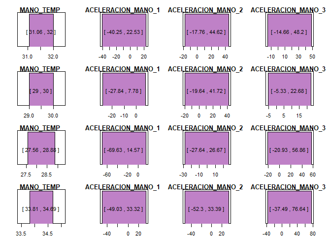

```r
#Grafico de la tabla resultante
plot(sym_pamap[1:4, ])
```

### b

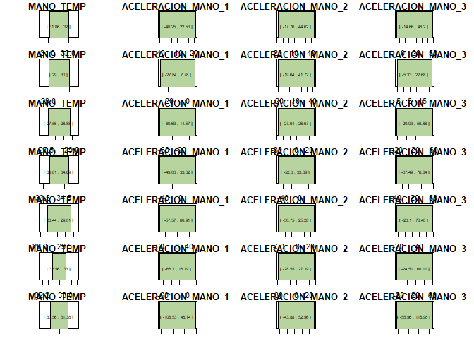

```r
# Se procede a graficar toda la tabla
plot(sym_pamap)
```

### c

```r
# Se procede a estimar la media sinbolica

lapply(sym_pamap, FUN = mean, method = "interval")
```

```
## $mano_temp
## <symbolic_interval[1]>
## [1] [30.43 : 31.39]
##
## $aceleracion_mano_1
## <symbolic_interval[1]>
## [1] [-59.93 : 29.24]
##
## $aceleracion_mano_2
## <symbolic_interval[1]>
## [1] [-31.50 : 36.00]
##
## $aceleracion_mano_3
## <symbolic_interval[1]>
## [1] [-26.00 : 65.71]
```

```r
# Se procede a estimar la mediana
lapply(sym_pamap, FUN = median, method = "interval")
```

```
## $mano_temp
## <symbolic_interval[1]>
## [1] [30.56 : 31.38]
##
## $aceleracion_mano_1
## <symbolic_interval[1]>
## [1] [-57.57 : 22.53]
##
## $aceleracion_mano_2
## <symbolic_interval[1]>
## [1] [-28.55 : 33.39]
##
## $aceleracion_mano_3
## <symbolic_interval[1]>
## [1] [-23.10 : 60.11]
```

```r
# Se procede a estimar la varianza
lapply(sym_pamap, FUN = var, method = "interval")
```

```
## $mano_temp
## <symbolic_interval[1]>
## [1] [5.11 : 4.10]
##
## $aceleracion_mano_1
## <symbolic_interval[1]>
## [1] [647.26 : 359.32]
##
## $aceleracion_mano_2
## <symbolic_interval[1]>
## [1] [156.59 : 112.98]
##
## $aceleracion_mano_3
## <symbolic_interval[1]>
## [1] [270.31 : 863.11]
```

```r
# Se procede a estimar la desviacion estandar
lapply(sym_pamap, FUN = sd, method = "interval")
```

```
## $mano_temp
## <symbolic_interval[1]>
## [1] [2.26 : 2.02]
##
## $aceleracion_mano_1
## <symbolic_interval[1]>
## [1] [25.44 : 18.96]
##
## $aceleracion_mano_2
## <symbolic_interval[1]>
## [1] [12.51 : 10.63]
##
## $aceleracion_mano_3
## <symbolic_interval[1]>
## [1] [16.44 : 29.38]
```

```r
# Se procede a estimar la desviacion estandar
cor(sym_pamap$mano_temp, sym_pamap$aceleracion_mano_1)
```

```
## [1] 0.03332648
```

### d

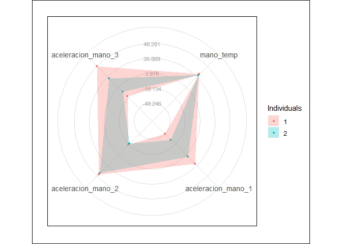

```r
# Se realiza un grafico de radar
sym.radar.plot(sym_pamap[1:2, ])
```

En este caso se puede observar que el individuo 1 en la actividad cycling presenta una mayor variabilidad en la mano. Sin embargo, la temperatura es similar.

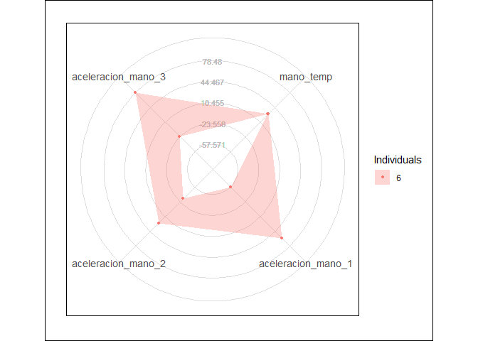

```r
# Se realiza un grafico de radar
sym.radar.plot(sym_pamap[5:5,])
```

### e

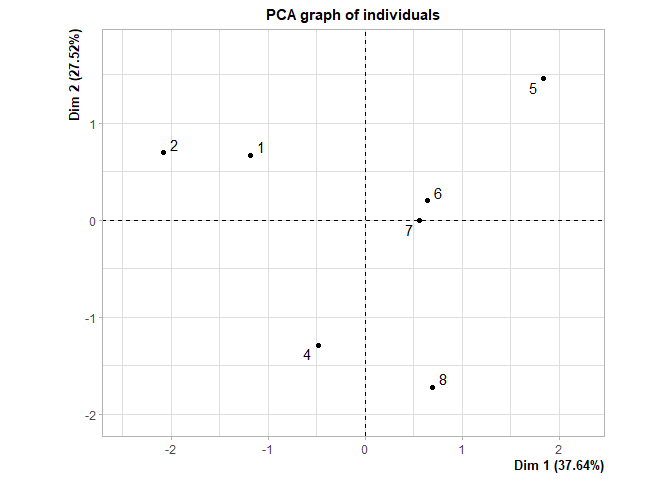

```r
# Se realiza un ACP con el metodo
# clasico
acp_classic_pamap <- sym.pca(sym_pamap, 'classic')
plot(acp_classic_pamap, choix='ind')
```

En este caso se puede obsservar qye los individuos 5 y 8 se encuentran claramente alejados de los demás. Los elementos 1 y 2, y 6 y 7 se ven más cercanos entre si.

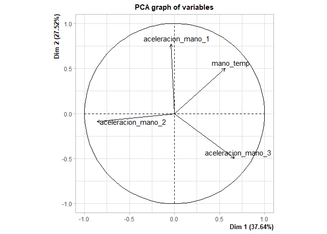

```r
plot(acp_classic_pamap, choix='var')
```

Todas las variables presentan un grado similar de representación. Sin embargo, todos presentan una correlación similar, salvo por temperatura que presenta mayor correlación con el eje 1 del aceletrometro de la mano.

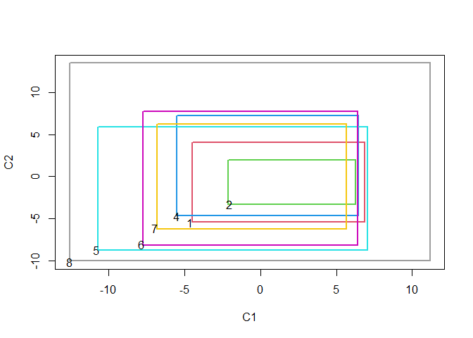

```r
# Se realiza un ACP con el metodo
# simbolico
acp_sym_pamap <- sym.pca(sym_pamap, method = 'centers')
plot(acp_sym_pamap, choix='ind')
```

Al observar este ACP se puede observar que el individuo 2 es el que muestra la menor variabilidad, mientras que el 8 presenta una mayor variabilidad.

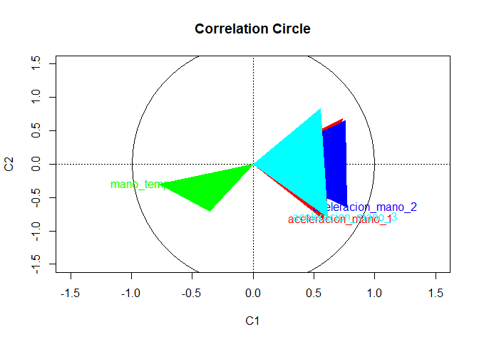

```r
plot(acp_sym_pamap, choix='var')
```

Se puede observar que todas las variables presentan una representación similar. Es interesante observar que la temperatura presenta en este caso un comporatamiento distinto a las otras variables y en este caso presenta la menor correlación con todos las demás variables. Las variables del del acelerómetro presentan una correalción similar entre si.

### f

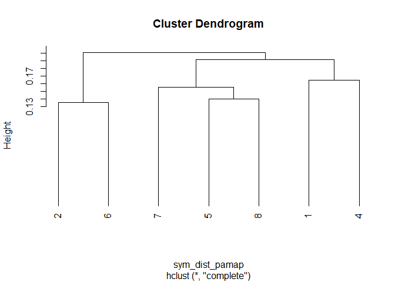

```r
# Se hace una clusterizacion jeraquica
sym_dist_pamap <- sym.dist.interval(sym.data = sym_pamap,
                        method = "Gowda.Diday")
sym_hclust_pamap <- hclust(sym_dist_pamap)
plot(sym_hclust_pamap, hang = -1)
```

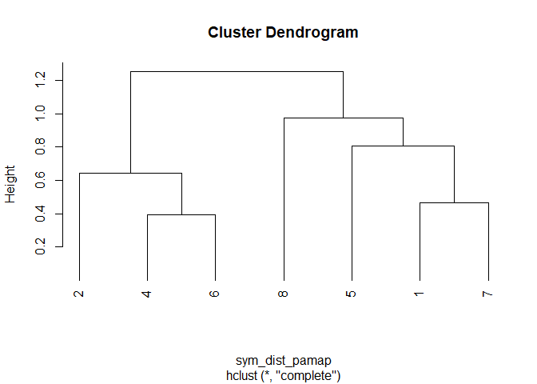

```r
#Billard distance
sym_dist_pamap <- sym.dist.interval(sym.data = sym_pamap,
                        method = "Ichino")
sym_hclust_pamap <- hclust(sym_dist_pamap)
plot(sym_hclust_pamap, hang = -1)
```

Aquí cambian los primeros conjuntos y se puede observar que hay una mayor variabilidad en las distancias. Los conjuntos formados por 4 y 6, y 1 y 7 tienen distancias similares.

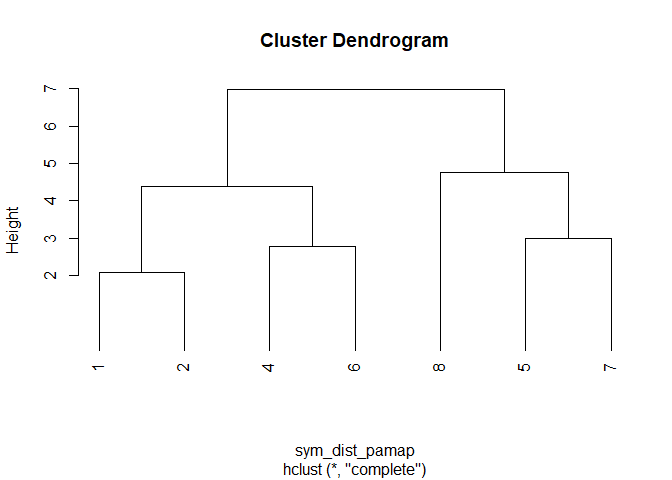

```r
#Billard distance
sym_dist_pamap <- sym.dist.interval(sym.data = sym_pamap,
                        gamma = 0.5,
                        method = "Hausdorff",
                        normalize = FALSE,
                        SpanNormalize = TRUE,
                        euclidea = TRUE,
                        q = 2)
sym_hclust_pamap <- hclust(sym_dist_pamap)
plot(sym_hclust_pamap, hang = -1)
```

Aquí se conserva el primero conjunto mostrado en la distancia de Ichino que es el de 4 y 6. Aquí también se puede observar mayor variabilidad en las distancias en comparación con la distancia Gowda-Diday.

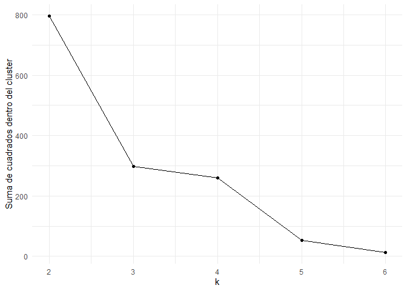

```r
tot.withinss <- c()
k <- c()

for(i in 2:6){

  # Se efectua un kmeans
   k <- c(k, i)
   tot.withinss <- c(tot.withinss,
    sym.kmeans(sym_pamap, k = i)$tot.withinss)
}

ggplot(, aes(x = k, tot.withinss)) +
  geom_point() +
  geom_line() +
  labs(x = "k", y = "Suma de cuadrados dentro del cluster")
```

Se observa que existe un codo en 3, entonces se toma k igual a 3.

```r
# Se efectua un kmeans
sym_kmeans_pamap <- sym.kmeans(sym_pamap, k = 3)
sym_kmeans_pamap$cluster
```

```
## 1 2 4 5 6 7 8
## 3 3 2 1 1 2 2
```

```r
sym_kmeans_pamap$centers
```

```
##   mano_temp aceleracion_mano_1 aceleracion_mano_2 aceleracion_mano_3
## 1  31.68750          -3.091225          -6.097825           23.63167
## 2  30.65625         -27.457500           1.158083           22.08943
## 3  30.51562          -9.444715          12.233725           12.72260
```

Se puede observar que ningún elemento queda solo.